# Client Report - Late flights and missing data

- Show All Code
- Hide All Code

Course DS 250

Author

Tad Decker

## Elevator pitch

At first glance the data we’ve collected about delayed airplane flights seem simple, but with a closer inspection we find some interseting informaiton. Atlanta may have the most delayed flights of the seven airports we evaluated, but when it comes to percent delayed, San Fransisco takes the cake.

**Read and format project data**

```python
df = pd.read_json("https://raw.githubusercontent.com/byuidatascience/data4missing/master/data-raw/flights_missing/flights_missing.json")
```

```python
# a = df.filter(['month']).query('month == "n/a"').value_counts()
# df.filter(['airport_name']).value_counts()
# df.filter(['year']).value_counts()

df.filter(['minutes_delayed_carrier']).query('minutes_delayed_carrier.isnull() == True', engine='python').shape[0]

df.filter(['year']).query('year.isnull() == True', engine='python').shape[0]
# e = df.filter(['minutes_delayed_nas']).query('minutes_delayed_nas == "n/a"').value_counts()

# print(a, b, c, d, e)
```

```
23
```

## Fix missing datatypes

Fix all of the varied missing data types in the data to be consistent (all missing values should be displayed as “NaN”).

In your report include one record example (one row) from your new data, in the raw JSON format. Your example should display the “NaN” for at least one missing value.

```python
df = df.replace(-999, np.nan)
df = df.replace('n/a', np.nan)

df[df.isin([np.nan]).any(axis=1)].head(1)
```

|  | airport_code | airport_name | month | year | num_of_flights_total | num_of_delays_carrier | num_of_delays_late_aircraft | num_of_delays_nas | num_of_delays_security | num_of_delays_weather | num_of_delays_total | minutes_delayed_carrier | minutes_delayed_late_aircraft | minutes_delayed_nas | minutes_delayed_security | minutes_delayed_weather | minutes_delayed_total |
| --- | --- | --- | --- | --- | --- | --- | --- | --- | --- | --- | --- | --- | --- | --- | --- | --- | --- |
| 0 | ATL | Atlanta, GA: Hartsfield-Jackson Atlanta Intern... | January | 2005.0 | 35048 | 1500+ | NaN | 4598 | 10 | 448 | 8355 | 116423.0 | 104415 | 207467.0 | 297 | 36931 | 465533 |

## Which airport has the worst delays?

Discuss the metric you chose, and why you chose it to determine the “worst” airport. Your answer should include a summary table that lists (for each airport) the total number of flights, total number of delayed flights, proportion of delayed flights, and average delay time in hours.

```python
sum_dat = df[['airport_code', 'num_of_delays_total', 'num_of_flights_total']].groupby('airport_code').sum().head(1000).reset_index().tail(10)

sum_dat['percent_delayed'] = ((sum_dat['num_of_delays_total'] / sum_dat['num_of_flights_total']) * 100).round(2)

mean_dat = df.groupby('airport_code')['minutes_delayed_total'].mean().reset_index().round(2)

mydat = pd.merge(sum_dat, mean_dat, on='airport_code').sort_values(by='percent_delayed', ascending=False)

airport_bar = px.bar(mydat, x='airport_code', y='percent_delayed').update_layout(xaxis_title="Airport Code", yaxis_title="Percent Delayed")
airport_bar.show()

display(mydat)
```

[interactive chart not shown]

|  | airport_code | num_of_delays_total | num_of_flights_total | percent_delayed | minutes_delayed_total |
| --- | --- | --- | --- | --- | --- |
| 5 | SFO | 425604 | 1630945 | 26.10 | 201140.10 |
| 3 | ORD | 830825 | 3597588 | 23.09 | 426940.37 |
| 0 | ATL | 902443 | 4430047 | 20.37 | 408969.14 |
| 2 | IAD | 168467 | 851571 | 19.78 | 77905.14 |
| 4 | SAN | 175132 | 917862 | 19.08 | 62698.85 |
| 1 | DEN | 468519 | 2513974 | 18.64 | 190707.43 |
| 6 | SLC | 205160 | 1403384 | 14.62 | 76692.20 |

## What is the best month to fly?

What is the best month to fly if you want to avoid delays of any length?

Discuss the metric you chose and why you chose it to calculate your answer. Include one chart to help support your answer, with the x-axis ordered by month. (To answer this question, you will need to remove any rows that are missing the Month variable.)

**Create graph to evaluate the best month to fly to avoid delays**

```python
# Filter out NaN values
df_months = df.query('month.isnull() == False', engine='python')

# Combine months and create columns for total flights, delayed flights, and percent delayed
df_months = df_months.groupby('month').agg(
  num_of_flights_total = ('num_of_flights_total', 'sum'),
  num_of_delays_total = ('num_of_delays_total', 'sum')
  ).reset_index()

df_months['percent_delayed'] = ((df_months['num_of_delays_total'] / df_months['num_of_flights_total']) * 100).round(2)

# 'February' is spelt wrong, so fix that
df_months = df_months.replace('Febuary', 'February')

# Create bar chart
month_bar = px.bar(df_months, x='month', y='percent_delayed')

# Put months in order and display!
months_in_order = ['January', 'February', 'March', 'April', 'May', 'June', 'July', 'August', 'September', 'October', 'November', 'December']

month_bar.update_xaxes(categoryorder='array', categoryarray=months_in_order)
month_bar.update_layout(xaxis_title='Month', yaxis_title='Percent Delayed')

month_bar.show()
```

[interactive chart not shown]

For my metric, I chose to plot the total percent of delayed flights in the data set for each month. I wanted to make sure I choose a month that had fewer delayed flights, but only because it had fewer total flights, not because it was a better month. After plotting, we can see that the best months to fly if you want to avoid delays are September and November.

## Create column of total flights delayed by weather

Your job is to create a new column that calculates the total number of flights delayed by weather (both severe and mild).

**Create new row that is total number of flights delayed because of weather**

```python
# Get mean num_of_delays_late_aircraft
mean_late_air_craft = df['num_of_delays_late_aircraft'].mean()

# Replace every NaN value with the mean
df['num_of_delays_late_aircraft'] = df['num_of_delays_late_aircraft'].replace(np.nan, mean_late_air_craft)

df['num_of_delays_late_aircraft'].head()

# Months from April to August
april_to_august = ['April', 'May', 'June', 'July', 'August']

# Calculate num_of_delays_weather_total with the criteria given in the question
df['num_of_delays_weather_total'] = df['num_of_delays_weather'] + (df['num_of_delays_late_aircraft'] * .3) + np.where(df['month'].isin(april_to_august), df['num_of_delays_nas'] * .4, df['num_of_delays_nas'] * .6)

# Display first five rows in a table
display(df
  .head(5)
  .filter(["airport_code", "num_of_delays_nas","month", "num_of_delays_weather_total"]))
```

|  | airport_code | num_of_delays_nas | month | num_of_delays_weather_total |
| --- | --- | --- | --- | --- |
| 0 | ATL | 4598 | January | 3539.531222 |
| 1 | DEN | 935 | January | 1072.400000 |
| 2 | IAD | 895 | January | 915.400000 |
| 3 | ORD | 5415 | January | 4231.500000 |
| 4 | SAN | 638 | January | 642.800000 |

## Barplot display

Using the new weather variable calculated above, create a barplot showing the proportion of all flights that are delayed by weather at each airport. Discuss what you learn from this graph.

**Graph num_of_delays_weathe[_total on a barplot**

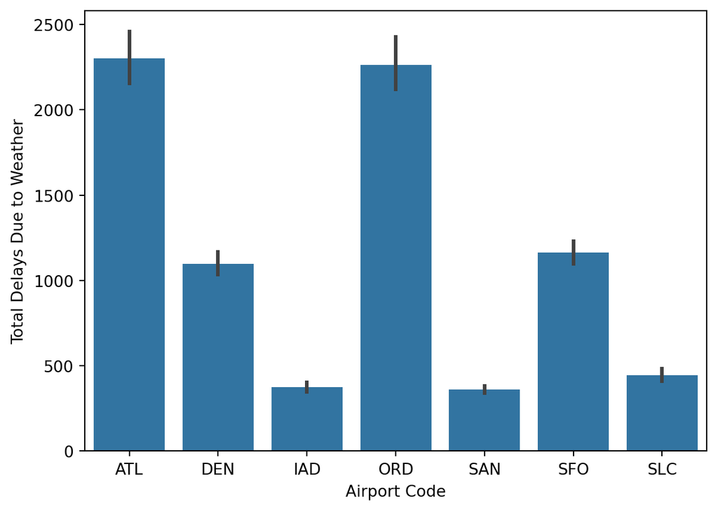

Total flights delayed by weather barplot

```python
barplot = sns.barplot(df[['airport_code', 'num_of_delays_weather_total']], x='airport_code', y='num_of_delays_weather_total')

barplot.set(xlabel='Airport Code', ylabel='Total Delays Due to Weather')
plt.show()
```

As displayed in this graph, after calculating the total number of flights delayed by weather we can see that Atlanta and O’Hare International Airport have the worst amounts of flights due to weather. Denver and San Fransisco are second with nearly half the amount, with Dulles, San Diego, and Salt Lake City in third, by about another half.

Back to top